# MATHTOOLS

### Ex: Random walk

Back to Top

```python
from numpy import zeros, append, cumsum
import numpy.random as rd

randomwalk = lambda T, p=0.5, X0=0: append([X0], cumsum(rd.choice([-1.0,1.0], T, p=[1-p, p])))
# Appending cumulative sum of random choices to end of list [X0],
# T=10 -> 11 elements

rd.seed(1)
print(randomwalk(10))
```

```
[ 0. -1.  0. -1. -2. -3. -4. -5. -6. -7. -6.]
```

### Ex: 2-dim random walk

Back to Top

```python
import numpy as np
import numpy.random as rd

displacement = np.array([[-1, 0], [1, 0], [0, -1], [0, 1]])

# return X0, ..., XT
def RandomWalk2(T, X0=np.array([0,0])):
    X = np.zeros([T+1, 2])
    X[0,:] = X0
    for i in range(1, T+1):
        k = rd.choice([0,1,2,3])
        X[i, :] = X[i-1, :] + displacement[k, :]
    return X

print(RandomWalk2(10))
```

```
[[ 0.  0.]
 [ 0. -1.]
 [ 1. -1.]
 [ 1. -2.]
 [ 0. -2.]
 [ 0. -1.]
 [-1. -1.]
 [-1. -2.]
 [-2. -2.]
 [-1. -2.]
 [-1. -3.]]
```

### Ex: 10 particles taking 2d random walk (Discrete brownian motion)

Back to Top

[video not shown]

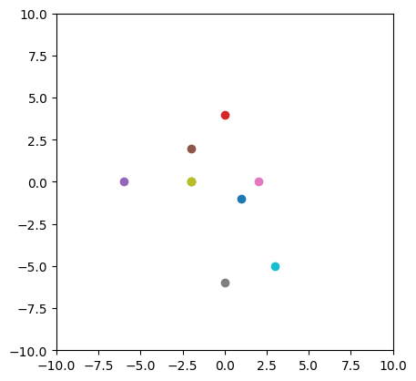

```python
from numpy import array, zeros
from numpy.random import choice

displacement = array([[-1, 0], [1, 0], [0, -1], [0, 1]])

# return X0, ..., XT
def RandomWalk2(T, X0=array([0,0])):
    X = zeros([T+1, 2])
    X[0,:] = X0
    for i in range(1, T+1):
        k = choice([0,1,2,3])
        X[i, :] = X[i-1, :] + displacement[k, :]
    return X

from matplotlib.animation import FuncAnimation
from matplotlib.pyplot import subplots, plot
from matplotlib.lines import Line2D

# create a plot to animate, ax is the axis object
fig, ax = subplots()

# set the limits of the axes
ax.set_xlim(-10,10)
ax.set_ylim(-10,10)
ax.set_aspect(1)

for i in range(10):
    plot([0], [0], 'o')

def update(frame):
    for i in range(len(ax.lines)):
        x, y = ax.lines[i].get_data() # Lab: Ask what is meant by ax.lines[i]
        k = choice([0,1,2,3])
        d = displacement[k]
        ax.lines[i].set_data([x[0] + d[0]], [y[0] + d[1]])

anim = FuncAnimation(fig, update, frames=range(0, 20))
from IPython.display import HTML
HTML(anim.to_html5_video())
```

### Ex: Rain drops in lake

Back to Top

[video not shown]

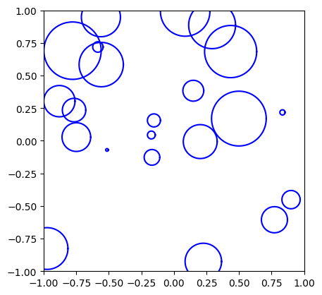

```python
from matplotlib.animation import FuncAnimation
from matplotlib.pyplot import subplots
from numpy import linspace, sin, cos
from math import pi
from numpy.random import *

# create a plot to animate, ax is the axis object
fig, ax =subplots()

# set the limits of the axes
ax.set_xlim([-1,1])
ax.set_ylim([-1,1])
ax.set_aspect(1)

# these two lines define a function circle that produces the xand y coordinates of points on a circle
# centered xc and yc, with a radius r
theta = linspace(0, 2*pi, 100)
circle = lambda xc, yc, r: [r*cos(theta)+xc,r*sin(theta)+yc]

# No circles:
# def update(frame):
#     x, y = ax.lines[0].get_data()
#     k = choice([0,1,2,3])
#     if k == 0:
#         x = x-1
#     if k == 1:
#         x = x+1
#     if k == 2:
#         y = y-1
#     if k == 3:
#         y = y+1
#     ax.lines[0].set_data(x, y)

def update(frame):
    # check the radius of previous circles
    for l in ax.lines:
        l.r = l.r + 0.01
        x, y = circle(l.xc, l.yc, l.r)
        l.set_data(x, y)
    # add a new circle
    xc, yc = 2*random(2)-1
    x, y = circle(xc, yc, 0.01)
    p = ax.plot(x, y, '-b')
    # we save the center and raius of each circle as the instant variables in each line
    p[0].xc = xc
    p[0].yc = yc
    p[0].r = 0.01

anim = FuncAnimation(fig, update, frames=range(0, 20))
from IPython.display import HTML
HTML(anim.to_html5_video())
```

### `binomial` random variables

Back to Top

```python
# binomial(n,p) draws single bin w n trials, success probability p
# binomial(n,p,size) draws size binomial rn's, returns as array
# binomial(n, p, [m,n]) fills mxn matrix w binomial rn's
import numpy.random as rd

print(rd.binomial(7, 0.9))
print(rd.binomial(7, 0.9, 4))
print(rd.binomial(7, 0.9, [3,3]))
```

```
7
[7 5 7 5]
[[6 6 7]
 [5 7 6]
 [7 7 5]]
```

### Ex: SIR model w binomials

Back to Top

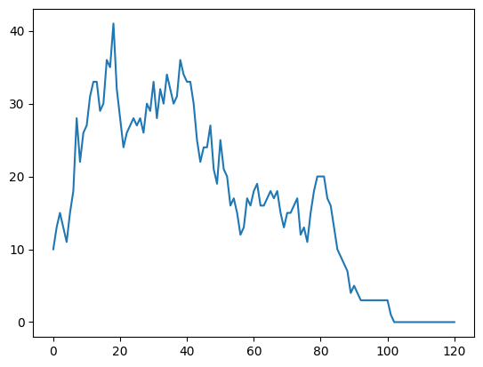

```python
from numpy.random import binomial
import numpy as np
import matplotlib.pyplot as plt
# simulate the SIR epidemic process for the time 0, 1, , T
# with an intial state (S0, I0, R0), and parameters
# beta (the transmission rate) and gamma (the recovery rate)
def SIR(T, S0, I0, R0, beta, gamma):
    S = np.zeros(T+1)
    S[0] = S0
    I = np.zeros(T+1)
    I[0] = I0
    R = np.zeros(T+1)
    R[0] = R0
    N = S0 + I0 + R0
    for i in range(1, T+1):
        X = binomial(S[i-1], 1 - np.exp(-beta*I[i-1]/N)) # Bin(num trials, probability of success)
        Y = binomial(I[i-1], gamma)
        S[i] = S[i-1] - X
        I[i] = I[i-1] + X - Y
        R[i] = R[i-1] + Y
    return S, I, R

S, I, R = SIR(120, 990, 10, 0, 0.3, 0.25)
plt.plot(np.linspace(0, 120, 121), I)
```

### Ex: 100 paths random walk

Back to Top

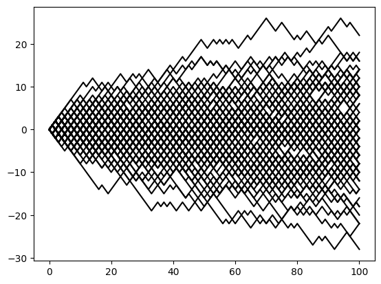

```python
randomwalk = lambda T, p=0.5, X0=0: \
    append([X0], cumsum(rd.choice([-1.0,1.0], T, p=[1-p, p])))

# We store the paths in a matrix X, where
# each row is a path, each column corresponds to a time step

from numpy import zeros
X = zeros([100, 101])

from matplotlib.pyplot import plot

time = range(101)
for i in range(100):
    X[i,:] = randomwalk(100)
    plot(time, X[i,:], '-k') # Plots each individual path by row of X

# # the mean
# from numpy import mean
# M = zeros(101)
# for i in time:
#     M[i] = mean(X[:,i])
# plot(time, M, "-r")

# # the standard deviation
# from numpy import std
# S = zeros(101)
# for i in time:
#     S[i] = std(X[:,i])
# plot(time, S, "-b", time, -S, "-b")
```

### Ex: Population of bacteria

Back to Top

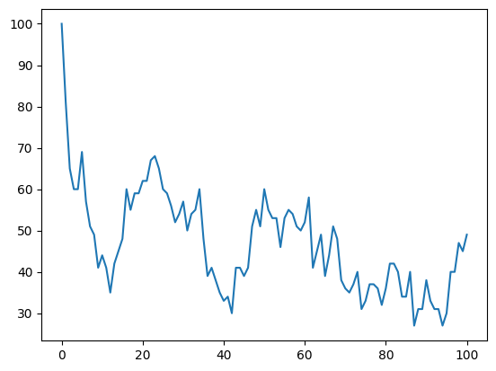

```python
# A new individual divides w probability b,
# Survives to next day w probability d = se^-aN(t)

import numpy as np, numpy.random as rd
import matplotlib.pyplot as plt
N, b, s, a = 100, 0.5, 0.8, 0.01

n = np.zeros(101)
n[0] = N

# Plot
for i in range(0, 100):
    d = s * np.exp(-a * n[i])
    survived = rd.binomial(n[i], d) # Num = previous pop, p = survival probability
    offspring = rd.binomial(n[i], b) # Num = previous pop, p = divides probability
    n[i+1] = survived + offspring

plt.plot(range(0, 101), n)
```

### `normal` random variables

Back to Top

```python
# normal(loc=0, scale=1) (note defaults) draws normal rv w mean loc, sd scale
# normal(loc, scale, size=10) draws array of n normal rv'S
# normal(loc,scale,size=[m,n])... mxn matrix

from numpy.random import normal
# genrate a normal random number with mean 2 and std 4
print(normal(2, 4))
# generate 10 standard normal random numbers
print(normal(size=10))
# generate 5x2 matrix of standard normal random numbers
print(normal(size=[5,2]))
```

```
1.8409992508256265
[ 0.42039196  0.4393437  -0.2950623  -1.34668495  0.70216252  0.14921719
  0.76315186  0.1056527   0.56286957 -1.33439575]
[[ 0.1570357  -0.28680977]
 [-0.51349663  0.08337221]
 [-1.31806702 -0.07211808]
 [ 0.66716613 -0.43646108]
 [-0.3804175  -0.4742338 ]]
```

### `diff` function

Back to Top

Returns array [x[1]-x[0], x[2]-x[1], ...], see example below

### Ex: Brownian motion (diffusion)

Back to Top

By definition, $\{B_{t_i}\}_{i=0^n}$ is a cumulative sum of $n$ normal random variables with mean $0$ and variance $h\sigma^2$;

$B_t =$ position at time $t$, then $B_{t_2}-B_{t_1}$ (displacement) is distributed normally; $\sim\text{Normal}(0, \; \sqrt{(t_2-t_1)\sigma^2)}$; $B_{t_i} = B_{t_(i-1)} + X_i$

```
(0.0, 100.0, -30.0, 30.0)
```

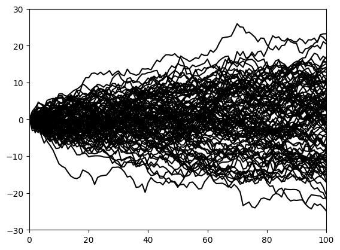

```python
from numpy import zeros, linspace, cumsum, diff, sqrt
from numpy.random import *

# t is an array of time points, B0=B(t[0])
def Brownian(t, sigma, B0):
    n = len(t)
    N = zeros(n)
    # compute the time steps t[1]-t[0], t[2]-t[1], ...
    dt = diff(t)
    # initial position
    N[0] = B0
    # the increments, i.e., the step sizes
    N[1:n] = normal(0, sigma*sqrt(dt), n-1)
    # Note: Normal expects std. deviation thus must be sqrt(sigma^2 * dt)
    return cumsum(N)

from matplotlib.pyplot import plot, axis

t = linspace(0, 100, 101)
for i in range(0, 100):
    plot(t, Brownian(t, 1, 0), '-k')
axis([0, 100, -30, 30])
```

### Ex: Graphing density of diffusing particles (Brownian motion) in intervals

Back to Top

[video not shown]

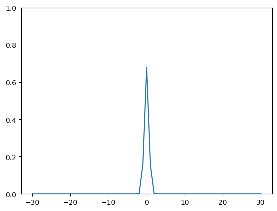

```python
from numpy import zeros, linspace, cumsum, diff, sqrt
from numpy.random import *
from matplotlib.pyplot import *

# t is an array of time points, B0=B(t[0])
def Brownian(t, sigma, B0):
    n = len(t)
    N = zeros(n)
    # compute the time steps t[1]-t[0], t[2]-t[1], ...
    dt = diff(t)
    # initial position
    N[0] = B0
    # the increments, i.e., the step sizes
    N[1:n] = normal(0, sigma*sqrt(dt), n-1)
    # Note: Normal expects std. deviation thus must be sqrt(sigma^2 * dt)
    return cumsum(N)


X = zeros([10000, 101])
t = linspace(0, 100, 101)
for i in range(0, 10000):
    X[i,:] = Brownian(t, 0.5, 0)

def count(x):
    c = zeros(61)
    for v in x:
        i = int(round(v)) + 30
        if i >=0 and i < 61:
            c[i] = c[i] + 1
    return c/10000

from matplotlib.animation import FuncAnimation

fig, ax = subplots()
ax.set_ylim([0, 1])

line = plot(linspace(-30, 30, 61), count(X[:,0]))

def update(t):
    line[0].set_ydata(count(X[:,t]))

anim = FuncAnimation(fig, update, frames=range(1, 101))

from IPython.display import HTML
HTML(anim.to_html5_video())
```

### Ex: Brownian motion lab

Back to Top

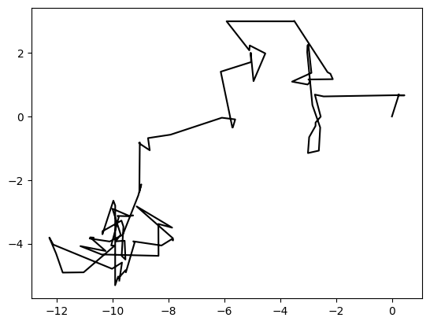

```python
import numpy as np
import matplotlib.pyplot as plt

t, sigma, init = np.linspace(0, 100, 101), 1, [0,0]
dt = np.diff(t)
displacement = lambda n: np.random.uniform(0, 2*np.pi, n)
r = lambda n: normal(0, sigma*np.sqrt(dt), n)
step = lambda n: np.random.normal(0, dt, n)

def brownian2d(t, sigma, init):
    n = len(t)
    # displacement = random(n-1)*2*np.pi
    # r = normal(0, sigma*np.sqrt(dt), n-1)
    xs = np.zeros(n)
    ys = np.zeros(n)
    xs[0] = init[0]
    ys[0] = init[1]
    xs[1:n] = step(n-1) * r(n-1)*np.cos(displacement(n-1))
    ys[1:n] = step(n-1) * r(n-1)*np.sin(displacement(n-1))
    return np.cumsum(xs), np.cumsum(ys)

xs, ys = brownian2d(t, sigma, init)
plt.plot(xs, ys, "-k")
```

[video not shown]

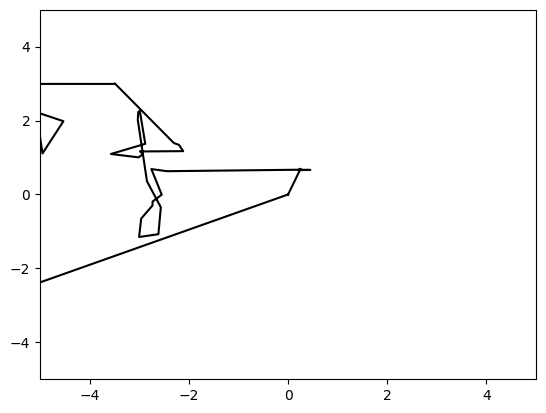

```python
import matplotlib.pyplot as plt
from matplotlib.animation import FuncAnimation
import numpy as np

fig, ax = plt.subplots()

plt.xlim(-5,5)
plt.ylim(-5,5)

x = []
y = []

line, = plt.plot(x, y, '-k')

def update(frame):
    x.append(xs[frame])
    y.append(ys[frame])
    line.set_data(x, y)
    return line,

anim = FuncAnimation(fig, update, frames=100, interval = 50)
from IPython.display import HTML
HTML(anim.to_html5_video())
```

## Symbolic calculation

Back to Top

### `sympy` symbols

Back to Top

```python
# symbol is object of symbol class
from sympy import *
from IPython.display import display

# an integer x1
x1 = Symbol("x1", integer=True)
# a symbol alpha without assumptions
a = Symbol("alpha")
print(x1, a)
display(x1, a)

# Multiple symbols
x, y, z =symbols("x y z")
a, b = symbols("a, b")
c = symbols("c", real=True)
d0, d1, d2=symbols("d:3") # same as "d0:3"
print(d0, d1, d2)
display(d0, d1, d2)
```

```
x1 alpha
```

$\displaystyle x_{1}$

$\displaystyle \alpha$

```
d0 d1 d2
```

$\displaystyle d_{0}$

$\displaystyle d_{1}$

$\displaystyle d_{2}$

### `sympy` expressions

Back to Top

```python
# Expressions are also objects
import sympy as sp

# here cos(1) is not evaluated as a number (sp.cos(1))
display(sp.cos(1))

a, b = sp.symbols("a, b")

e=a+b
display(e)
display(a+1, a*b, a/b, sp.sin(a+b), sp.exp(a/b))
```

$\displaystyle \cos{\left(1 \right)}$

$\displaystyle a + b$

$\displaystyle a + 1$

$\displaystyle a b$

$\displaystyle \frac{a}{b}$

$\displaystyle \sin{\left(a + b \right)}$

$\displaystyle e^{\frac{a}{b}}$

### Simplifying expressions

Back to Top

```python
from sympy import *

x, y = symbols("x, y")
display(cos(x)**2 + sin(x)**2)
display(simplify(cos(x)**2 + sin(x)**2))
```

$\displaystyle \sin^{2}{\left(x \right)} + \cos^{2}{\left(x \right)}$

$\displaystyle 1$

### Solving equations

Back to Top

```python
# solve (eq, var), eq is equation  or expression
# i.e. Eq(a, y) : a=y
# If eq is expression, equivalent to Eq(eq, 0)
# Solves for var, ret's list of solution
from sympy import *
x, a = symbols("x, alpha")

roots = solve(x**2-a, x) # Solves x**2 = a for x
display(roots)
display(roots[0], roots[1])
```

```
[-sqrt(alpha), sqrt(alpha)]
```

$\displaystyle - \sqrt{\alpha}$

$\displaystyle \sqrt{\alpha}$

+ Note: Note all equations can be solved symbolically, i.e. sinx = x

```python
solve(sin(x)-x, x)
```

[output not shown]

### Solving linear systems

Back to Top

```python
# linsolve(equations, variables) solves system,
# equations is a list of eqns
# variable is a tuple or list of variables
from sympy import *
alpha, beta, gamma, x, y, z = symbols('alpha, beta, gamma, x, y, z')

r = linsolve([alpha*x+beta*y+gamma*z, Eq(x+y+z,2), Eq(x-y,1)], [x,y,z])
display(r)
print(r)

# Note: Is a FiniteSet object, must be indexed w .args
display(r.args[0], r.args[0][0], r.args[0][1], r.args[0][2])
```

$\displaystyle \left\{\left( \frac{\beta - 3 \gamma}{\alpha + \beta - 2 \gamma}, \ \frac{- \alpha - \gamma}{\alpha + \beta - 2 \gamma}, \ \frac{3 \alpha + \beta}{\alpha + \beta - 2 \gamma}\right)\right\}$

```
{((beta - 3*gamma)/(alpha + beta - 2*gamma), (-alpha - gamma)/(alpha + beta - 2*gamma), (3*alpha + beta)/(alpha + beta - 2*gamma))}
```

$\displaystyle \left( \frac{\beta - 3 \gamma}{\alpha + \beta - 2 \gamma}, \ \frac{- \alpha - \gamma}{\alpha + \beta - 2 \gamma}, \ \frac{3 \alpha + \beta}{\alpha + \beta - 2 \gamma}\right)$

$\displaystyle \frac{\beta - 3 \gamma}{\alpha + \beta - 2 \gamma}$

$\displaystyle \frac{- \alpha - \gamma}{\alpha + \beta - 2 \gamma}$

$\displaystyle \frac{3 \alpha + \beta}{\alpha + \beta - 2 \gamma}$

```python
# Ex w no solns:
linsolve([alpha*x+beta*y+gamma*z, Eq(x+y+z,2), Eq(x-y,1)], [x,y])
```

$\displaystyle \emptyset$

### Ex: Solving two eqns in three variables

Back to Top

\begin{align*} \alpha x +\beta y + \gamma z &=1\\ x+y+z & = 0\\ \end{align*}

```python
from sympy import *
from sympy.abc import x, y, z, alpha, beta, gamma
from IPython.display import display

fn = alpha*x + beta*y + gamma*z
soln = linsolve([Eq(fn, 1), x+y+z], (x,y,z))

display(soln)


f = soln.args[0]
x, y, z = f

display(x, y, z)
```

$\displaystyle \left\{\left( \frac{z \left(\beta - \gamma\right)}{\alpha - \beta} + \frac{1}{\alpha - \beta}, \ \frac{z \left(- \alpha + \gamma\right)}{\alpha - \beta} - \frac{1}{\alpha - \beta}, \ z\right)\right\}$

$\displaystyle \frac{z \left(\beta - \gamma\right)}{\alpha - \beta} + \frac{1}{\alpha - \beta}$

$\displaystyle \frac{z \left(- \alpha + \gamma\right)}{\alpha - \beta} - \frac{1}{\alpha - \beta}$

$\displaystyle z$

### Solving nonlinear systems

Back to Top

```python
# nonlinsolve(same deal as linsolve, & not all solvable)
from sympy import *
alpha, beta, gamma, x, y, z = symbols('alpha, beta, gamma, x, y, z')
# x**2 + y**2 = 1, xy = alpha
x = nonlinsolve([x**2+y**2-1, Eq(x*y, alpha)], [x,y])
display(x)
```

$\displaystyle \left\{\left( \frac{\left(\frac{1}{4} - \frac{\sqrt{1 - 4 \alpha^{2}}}{4}\right) \sqrt{2 \sqrt{1 - 4 \alpha^{2}} + 2}}{\alpha}, \ \sqrt{\frac{\sqrt{1 - 4 \alpha^{2}}}{2} + \frac{1}{2}}\right), \left( \frac{\sqrt{2 - 2 \sqrt{1 - 4 \alpha^{2}}} \left(- \frac{\sqrt{1 - 4 \alpha^{2}}}{4} - \frac{1}{4}\right)}{\alpha}, \ - \sqrt{\frac{1}{2} - \frac{\sqrt{1 - 4 \alpha^{2}}}{2}}\right), \left( \frac{\sqrt{2 - 2 \sqrt{1 - 4 \alpha^{2}}} \left(\frac{\sqrt{1 - 4 \alpha^{2}}}{4} + \frac{1}{4}\right)}{\alpha}, \ \sqrt{\frac{1}{2} - \frac{\sqrt{1 - 4 \alpha^{2}}}{2}}\right), \left( \frac{\left(\frac{\sqrt{1 - 4 \alpha^{2}}}{4} - \frac{1}{4}\right) \sqrt{2 \sqrt{1 - 4 \alpha^{2}} + 2}}{\alpha}, \ - \sqrt{\frac{\sqrt{1 - 4 \alpha^{2}}}{2} + \frac{1}{2}}\right)\right\}$

### Substitution

Back to Top

```python
# subs: Subs a symbol w a value,
# Takes dictionary aa input, key is variable & value is val
from sympy import *
a, b, x, y = symbols("a, b, x, y")

e = a+b
display(e)

e.subs({a:x**2, b:y**2})
```

$\displaystyle a + b$

$\displaystyle x^{2} + y^{2}$

### Numerical evaluation: subs & lambdify

Back to Top

```python
# Method 1: subs
from sympy import *
a, b = symbols("a, b")

e = a+b
display(e)
e.subs({a:1, b:2})
```

$\displaystyle a + b$

$\displaystyle 3$

```python
# Method 2: Use lambdify
# lambdify(vars, e)
# vars: arguments, e: expression
from sympy import *
x, y = symbols("x, y")

f = lambdify([x, y], sqrt(x**2+y**2))
f(2, 2)
```

```
2.8284271247461903
```

```python
# Note: does not work with free symbols!

# this does not work because alpha is a free symbol
f = lambdify([x, y], sqrt(x**2+y**2-alpha))
f(2, 2)
```

[output not shown]

### Ex: Solve for radius r as function of x

Back to Top

$$ x^2\sin^2x+r^2-r^4=0 $$

```python
# Import, define symbols, function
from sympy import *
x, r = symbols('x, r')
f = x**2 * sin(x)**2 + r**2 - r**4

# Solve f to find roots
roots = solve(f, r)

# Holds soln
rts = []

# Check if real, positive (no negative radius) by subbing x=1,
# append solution to rts
for i in range(len(roots)):
    if roots[i].subs({x:1}).is_real:
        if roots[i].subs({x:1}).is_positive:
            rts.append(roots[i])

# Make sure there is only one solution in rts
if len(rts) == 1:
    print("Solution: ")
    rt = Eq(r, rts[0])
    display(rt)
else:
    print("Multiple solutions found")


# .lhs, .rhs
display(rt.lhs, rt.rhs)
```

```
Solution:
```

$\displaystyle r = \sqrt{\frac{\sqrt{4 x^{2} \sin^{2}{\left(x \right)} + 1}}{2} + \frac{1}{2}}$

$\displaystyle r$

$\displaystyle \sqrt{\frac{\sqrt{4 x^{2} \sin^{2}{\left(x \right)} + 1}}{2} + \frac{1}{2}}$

Use above to creat egraph

### Ex: Equilibrium of SIR

Back to Top

+ Reminders:

- Difference equation $x_{t+1}=f(x_t)$
- Equilibrium: $x_t=x^*$, i.e., $x^*=f(x^*)$

Consider the SIR model with births and deaths \begin{align} S_{t+1}-S_t & = -\beta S_tI_t+\mu-\mu S_t\\ I_{t+1} -I_t & = \beta S_tI_t - \gamma I - \mu I \end{align} Thus, a fixed point satisfies \begin{align} 0 & = -\beta SI+\mu-\mu S\\ 0 & = \beta SI - \gamma I - \mu I \end{align}

```python
from sympy import *
mu, beta, gamma, S, I = symbols('mu, beta gamma, S, I')
eqS = -beta*S*I+mu-mu*S
eqI = beta*S*I - gamma*I - mu*I
E=nonlinsolve([eqS, eqI], [S, I])
display(E)

ES, EI = E.args[1]
print_latex(simplify(ES))
print_latex(simplify(EI))
```

$\displaystyle \left\{\left( 1, \ 0\right), \left( - \frac{- \mu + \frac{\mu \left(\beta - \gamma - \mu\right)}{\beta}}{\mu}, \ \frac{\mu \left(\beta - \gamma - \mu\right)}{\beta \left(\gamma + \mu\right)}\right)\right\}$

```
\frac{\gamma + \mu}{\beta}
\frac{\mu \left(\beta - \gamma - \mu\right)}{\beta \left(\gamma + \mu\right)}
```

This system has two equilibrium,

$E_1 = (1, 0)$,  
$E_2 = \left(\frac{\gamma + \mu}{\beta} , \ \frac{\mu \left(\beta - \gamma - \mu\right)}{\beta \left(\gamma + \mu\right)}\right)$

Given $\displaystyle\mu=\frac{1}{80\times 365}$ and $\gamma=0.25$, how does $E_I$ change with $\beta$?

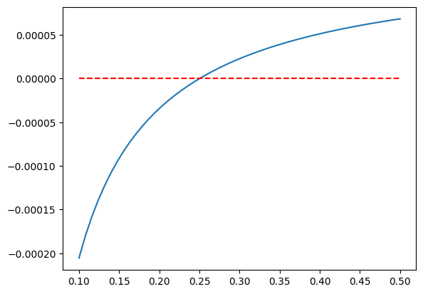

```python
f=lambdify(beta, EI.subs({gamma:0.25, mu:1.0/80/365}))
from numpy import linspace, zeros
b = linspace(0.1, 0.5, 51)

from matplotlib.pyplot import plot
plot(b, f(b), b, zeros(len(b)), "--r")
```

We see equilibrium of $I$ increases w $\beta$, to find critical point where $I>0$ solve $E_I(\beta)=0$

```python
solve(EI, beta)
```

```
[gamma + mu]
```

Thus if $\beta>\mu+\gamma$, then $I>0$

### Piecewise functions

Back to Top

$$ f(x)=\begin{cases} x-2, & x<2\\ x^2-1, & x\geq 2 \end{cases} $$

```python
from sympy import *

x = Symbol("x")
f = Piecewise((x-2, x<2), (x**2-1, x>=2))
display(f)
```

$\displaystyle \begin{cases} x - 2 & \text{for}\: x < 2 \\x^{2} - 1 & \text{otherwise} \end{cases}$

### Limits

Back to Top

```python
# limit(exp, s, e) calculates lim(from s to e) of exp
from sympy import *
from sympy.abc import t, a
display(limit(sin(x)/x, x, 0))

display(limit((sqrt(t-2)-1)/(t-3), t, 3))

# Note: Does NOT work with piecewise functions!

# oo : infty
display(limit(exp(-t), t, oo))
display(limit(sqrt(t+1)-sqrt(t), t, oo))
```

$\displaystyle 1$

$\displaystyle \frac{1}{2}$

$\displaystyle 0$

$\displaystyle 0$

### Derivatives/Differentiation

Back to Top

```python
# diff(f, x) calculates df/dx
# diff(f, x, n) calculates d^nf/dx^n
# diff(f, x, y, z) calculates mixed partial d^3f/dxdydz
from sympy import *
from sympy.abc import x

f = Piecewise((x-2, x<2), (x**2-1, x>=2))

display(f)
diff(f, x)

diff(cos(2*acos(x)), x)
```

$\displaystyle \begin{cases} x - 2 & \text{for}\: x < 2 \\x^{2} - 1 & \text{otherwise} \end{cases}$

$\displaystyle \frac{2 \sin{\left(2 \operatorname{acos}{\left(x \right)} \right)}}{\sqrt{1 - x^{2}}}$

### Implicit differentiation

Back to Top

```python
# idiff(f, y, x) compyutes y'(x) from f(x,y)=0
from sympy import *
from sympy.abc import x, y

cubic = x**3+y**3+2*x*y
display(cubic)
idiff(cubic, y, x)
```

$\displaystyle x^{3} + 2 x y + y^{3}$

$\displaystyle - \frac{3 x^{2} + 2 y}{2 x + 3 y^{2}}$

### Taylor series: `.series()`, `.removeO()` & `.expand()`

Back to Top

```python
# .series(x, x0, n) calculates taylor expression
# of variable x a x0 to degree n-1
from sympy import *
from sympy.abc import x, y

display(cos(2*acos(x*y)).series(x, 0, 6))

# The .removeO() method removed big O term
display(cos(2*acos(x*y)).series(x, 0, 6).removeO())

# Allows to expand further (Not in this example)
P = cos(2*acos(x*y)).series(x, 0, 6).removeO().series(y, 0, 6).removeO()
expand(P)
```

$\displaystyle -1 + 2 x^{2} y^{2} + O\left(x^{6}\right)$

$\displaystyle 2 x^{2} y^{2} - 1$

$\displaystyle 2 x^{2} y^{2} - 1$

+ Note: No higher order terms since in $[-1, 1]$ $$ cos(2cos^{-1}x) = 2x^2-1 $$

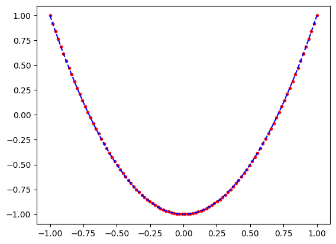

```python
f1 = lambdify([x], cos(2*acos(x)))
f2 = lambda x: 2*x*x -1

import numpy
from matplotlib.pyplot import plot
xx =numpy.linspace(-1, 1, 100)
plot(xx, f1(xx), ".r", xx, f2(xx), "--b")
```

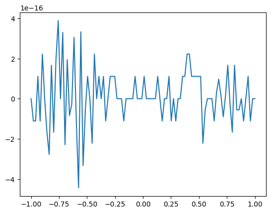

```python
# Accuracy:
plot(xx, f1(xx)-f2(xx), "-")
```

### Integration

Back to Top

```python
# integrate(f, x)
from sympy import *

# note that x is the only variable, we do not need to
# specify the integration variable
display(integrate(sin(x)**2))

r = Symbol("r")
display(integrate(x*exp(r*x), x))

# We can restrict r to be positive
r = Symbol("r", positive = True)
display(integrate(x*exp(r*x), x))

# integrate(f, (x, a, b)) calculates integral from a to b f(x)dx
display(integrate(cos(x), (x, -pi/2, pi/2)))
```

$\displaystyle \frac{x}{2} - \frac{\sin{\left(x \right)} \cos{\left(x \right)}}{2}$

$\displaystyle \begin{cases} \frac{\left(r x - 1\right) e^{r x}}{r^{2}} & \text{for}\: r^{2} \neq 0 \\\frac{x^{2}}{2} & \text{otherwise} \end{cases}$

$\displaystyle \frac{\left(r x - 1\right) e^{r x}}{r^{2}}$

$\displaystyle 2$

Let's calculate $\frac{d}{da}\int_0^{a^2} xe^{rx}dx$

```python
display(simplify(diff(integrate(x*exp(r*x), (x, 0, a**2)), a)))
```

$\displaystyle 2 a^{3} e^{a^{2} r}$

### Differential equations

Back to Top

+ Ex: malthus model
In a short period of time, the population growth is typically proportion to the population sizxe it self. Let $x(t)$ be the population size at time $t$, $$x'(t)=r x(t)$$

```python
from sympy import *
# dsolve(eq, ics={x(n):xn})
# eq : equation
# ics: initial conditions, dictionary form

# Note that in order to solve a differential,
# We need the variable of interest to be a function object
x = Function("x")

t = Symbol("t")
r = Symbol("r", positive=True)

# Above equation translated
Malthus = Eq(diff(x(t)), r*x(t))
display(Malthus)

# We use dsolve to solve differential equations
dsolve(Malthus)

x0 = Symbol("x0")
dsolve(Malthus, ics={x(0):x0})
```

$\displaystyle \frac{d}{d t} x{\left(t \right)} = r x{\left(t \right)}$

$\displaystyle x{\left(t \right)} = x_{0} e^{r t}$

+ We sub $r = a\left(1-\frac{x(t)}{K}\right)$ into the malthus model to obtain the logistic equation $x'(t)=ax(t)\left(1-\frac{x(t)}K\right),\; a>0$

```python
K = Symbol("K")
a = Symbol("a", positive=True)

logistic = Malthus.subs({r:a*(1-x(t)/K)})

display(logistic)
xt=dsolve(logistic, ics={x(0):x0})
display(xt)

# Compute limit:
print("RHS: ")
display(xt.args[0])
print("LHS:")
display(xt.args[1])
limit(xt.args[1], t, oo) # Note: oo: Infty
```

$\displaystyle \frac{d}{d t} x{\left(t \right)} = a \left(1 - \frac{x{\left(t \right)}}{K}\right) x{\left(t \right)}$

$\displaystyle x{\left(t \right)} = \frac{K x_{0} e^{a t}}{\left(- K + x_{0}\right) \left(\frac{x_{0} e^{a t}}{- K + x_{0}} - 1\right)}$

```
RHS:
```

$\displaystyle x{\left(t \right)}$

```
LHS:
```

$\displaystyle \frac{K x_{0} e^{a t}}{\left(- K + x_{0}\right) \left(\frac{x_{0} e^{a t}}{- K + x_{0}} - 1\right)}$

$\displaystyle K$

```python
# We verify that x(t) is a solution to the logistic model:

# Verify that x(t) is a solution.
simplify(logistic.subs({x(t):xt.args[1]}))
# Substituting xt into logistic to see if it gives equality;
# if yes, returns true.
```

$\displaystyle \text{True}$

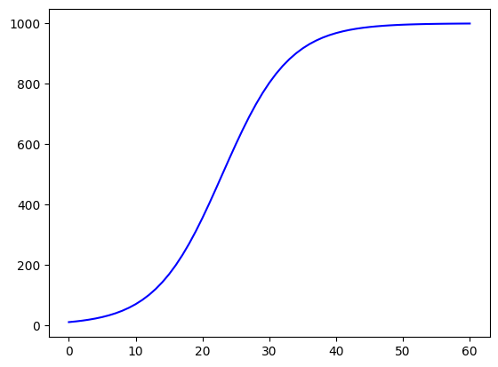

```python
# Plot solution

sol = lambdify([t, a, K, x0], xt.args[1])
# Easiest way to go from symbolic to numeric function;
# lambdify([params], function)

import numpy
from matplotlib.pyplot import plot

time = numpy.linspace(0, 60, 61)

plot(time, sol(time, 0.2, 1000, 10), "-b")
# Note: If x0 > k, pop decreases
# If x0 < k, pop 'levels off' at k
```

### Ex: Equilibrium of DE's

Back to Top

When $x'(t) = f(x(t))$; $x^* = f(x^*)$

+ Ex1: Logistic model $$x'=rx\left(1-\frac{x}{K}\right)$$ The equilibria must satisfy $$rx\left(1-\frac{x}{K}\right)=0$$ We can solve them using the solve function:

```python
display(logistic)

# the right hand side fo the equation is in .args[1]
RHS = logistic.args[1]
display(RHS)

# We have two solutions: x(t) = 0 and x(t)=K
solve(RHS, x(t))
```

$\displaystyle \frac{d}{d t} x{\left(t \right)} = a \left(1 - \frac{x{\left(t \right)}}{K}\right) x{\left(t \right)}$

$\displaystyle a \left(1 - \frac{x{\left(t \right)}}{K}\right) x{\left(t \right)}$

```
[0, K]
```

+ Ex2: SIRS model

```python
from sympy.abc import beta, gamma, rho, S, I, R
dS = -beta*S*I+rho*R
dI = beta*S*I-gamma*I
dR = gamma*I-rho*R

nonlinsolve([dS, dI, dR], [S, I, R])

# Solution 1: 0 infected, 0 recovered.
```

$\displaystyle \left\{\left( S, \ 0, \ 0\right), \left( \frac{\gamma}{\beta}, \ \frac{R \rho}{\gamma}, \ R\right)\right\}$

### Ex: CP's in sympy

Back to Top

$y = xlnx$

```python
from sympy import *

x = Symbol("x")

# y is an expression, not a symbol
y = x*log(x)

# dy is an expression, not a symbol
dy = diff(y, x)
display(dy)

# critical point is where dy=0
cp = solve(dy)
print("found", len(cp), "critical points")
for p in cp:
    display(p)

# 2nd derivatve test:
# ddy is y"
ddy = diff(y, x, 2)
# we evaluate ddy at the critical point
if ddy.subs({x:cp[0]}) > 0:
    print("minimum") # Positive means concave up, min
else:
    print("maximum") # Negative means concave down, max
```

$\displaystyle \log{\left(x \right)} + 1$

```
found 1 critical points
```

$\displaystyle e^{-1}$

```
minimum
```

### Ex: Moments, critical points, inflection

Back to Top

$$ f = \frac{1}{\sqrt{2\pi}\sigma}e^{-\frac{(x-\mu)^2}{2\sigma^2}} $$

```python
# scipy.integrate - quad(f, a, b)
# Most common: I,e = quad(f, a, b)
# (Evaluates integral of f(x) from a to b)

# Returns two val's:
# I, the integral
# e, the estimated error

from scipy.integrate import quad, dblquad, tplquad
from numpy import exp

g = lambda x:exp(x**3)
Ig, e = quad(g, 0, 1)
print(Ig, "error=", e)
```

```
1.3419044179774198 error= 1.4898131816847513e-14
```

### Ex: Mass and moments, constant density 1 (Full ex: Rolling wheel, Nov. 9)

Back to Top

#### Mass

$$m = \int\int\int_Vdzdydx$$

We use cylindrical coordiantes (i.e., polar coordinates for $y$ and $z$)

$$ y=r\cos\theta,\;z=r\sin\theta,\;\theta\in[0,2\pi]$$ and $$dzdydx = rd\theta drdx$$

$$M = \int_{-2}^2\int_{0}^{f(x)}\int_0^{2\pi}rd\theta drdx$$

#### Moment of inertia about the $x$-axis

$$I_x = \int\int\int_V(y^2+z^2)dzdydx$$

Using cylindrical coordiantes, $y^2+z^2 = r^2$, $$I_x = \int_{-2}^2\int_{0}^{f(x)}\int_0^{2\pi}(r^2)(r)d\theta drdx=\int_{-2}^2\int_{0}^{f(x)}\int_0^{2\pi}r^3drd\theta drdx$$

Back to Top

Back to Top

```python
from math import pi
from scipy.integrate import nquad

x = linspace(-2, 2, 401)
f = lambda x: sqrt((x**4+1)*(4-x**2))

# mass
m = nquad(lambda theta, r, x:r, [[0, 2*pi], lambda x: [0, f(x)], [-2, 2]])[0]
from math import pi
from scipy.integrate import nquad

# mass
m = nquad(lambda theta, r, x:r, [[0, 2*pi], lambda x: [0, f(x)], [-2, 2]])[0]

# moment of inertia
Ix = nquad(lambda theta, r, x:r**3, [[0, 2*pi], lambda x: [0, f(x)], [-2, 2]])[0]
print("m=", m, "Ix=", Ix)
# moment of inertia
Ix = nquad(lambda theta, r, x:r**3, [[0, 2*pi], lambda x: [0, f(x)], [-2, 2]])[0]
print("m=", m, "Ix=", Ix)
```

```
m= 79.46733417080468 Ix= 295.2925525544839
m= 79.46733417080468 Ix= 295.2925525544839
```

### Ex: Rod w radius profile...

Back to Top

A rod with a radius profile $$ x^2\sin^2x+r^2-r^4=0 $$ along its axis $x$, for $x\in[-3,3]$

```python
# Solve r as function of x symbolically

# Import, define symbols, function
from sympy import *
x, r = symbols('x, r')
f = x**2 * sin(x)**2 + r**2 - r**4

# Solve f to find roots
roots = solve(f, r)

# print(roots)
# Note we have identical positive and negative solutions
# This means the rod is symmetrical across the x-axis,
# for the sake of simplicity (assuming this is ok since next question
# asks to graph -r(x)) we will limit ourselves
# to the positive r(x)

# Holds soln
rts = []

# Check if real, positive by subbing x=1,
# append solution to rts
for i in range(len(roots)):
    if roots[i].subs({x:1}).is_real:
        if roots[i].subs({x:1}).is_positive:
            rts.append(roots[i])


# Make sure there is only one solution in rts
if len(rts) == 1:
    print("Solution: ")
    rx = Symbol('r(x)')
    rt = Eq(rx, rts[0])
    display(rt)
else:
    print("Multiple solutions found within constraints")
```

```
Solution:
```

$\displaystyle r(x) = \sqrt{\frac{\sqrt{4 x^{2} \sin^{2}{\left(x \right)} + 1}}{2} + \frac{1}{2}}$

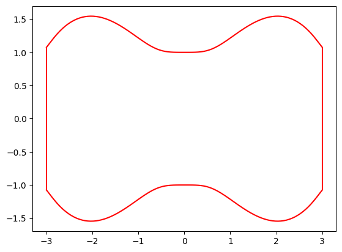

```python
# Define lambda function of r(x), plot cross section along x axis

# Use rhs of solution for lambdify
rx = lambdify(x, rt.rhs)
nrx = lambdify(x, -rt.rhs)

# Make x's, ys
import numpy as np
xs = np.linspace(-3, 3, 101)
ys = rx(xs)

# Make edges:
# Find max/mins
mn, mx = nrx(3), rx(3)

import matplotlib.pyplot as plt
fig, ax = plt.subplots()

plt.vlines(-3, mn, mx, "r")
plt.vlines(3, mn, mx, "r")
plt.plot(xs, ys, "-r", xs, -ys, "-r")
# plt.plot(xs, -ys)
```

```python
# Calculate derivative r'(x), numerically find max radius

# Differentiate RHS of equation
drr = Symbol("r(x)'")
drt = diff(rt.rhs, x)
dr = Eq(drr, drt)
display(dr)

# Find maxs
from scipy.optimize import fsolve
drx = lambdify(x, dr.rhs)
x2 = fsolve(drx, 2)
x1 = fsolve(drx, -2)

print("Max's occur at (", x1[0],",", rx(x1)[0], ") and (", x2[0],",", rx(x2)[0], ")")
```

$\displaystyle r(x)' = \frac{4 x^{2} \sin{\left(x \right)} \cos{\left(x \right)} + 4 x \sin^{2}{\left(x \right)}}{4 \sqrt{4 x^{2} \sin^{2}{\left(x \right)} + 1} \sqrt{\frac{\sqrt{4 x^{2} \sin^{2}{\left(x \right)} + 1}}{2} + \frac{1}{2}}}$

```
Max's occur at ( -2.0287578381104345 , 1.545039926252222 ) and ( 2.0287578381104345 , 1.545039926252222 )
```

```python
# Area of cross section;

# Area will be 2 * double integral with x bounds -3 to 3,
# y bounds 0 to r(x)
from scipy.integrate import dblquad

f = lambda y, x: 1
I,e = dblquad(f, -3, 3, nrx, rx)

print("Area: ", I)
```

```
Area:  15.494437829868373
```

```python
# Moment of inertia about x-axis

# Assuming a constant density of 1 (As in lecture Nov.9),
# We have Ix = double integral y**2 dA

f = lambda y, x: y**2
I,e = dblquad(f, -3, 3, nrx, rx)

print("Moment of inertia about x: ", I)
```

```
Moment of inertia about x:  9.208749260167275
```

# **PART 3**

Back to Top

## Libraries

Back to Top

```python
# Scipy
from scipy import integrate
# Used for
# - quad(f, a, b)
# - dblquad(f, a, b, c, d) (Lo to hi, ourside to inside)
# - tplquad(...)
from scipy import optimize
# Used for
# - linprog(c, A_ub, b_ub, A_eq, b_eq, bounds)
from scipy.optimize import linprog
```

## Numerical integration (Quadrature)

Back to Top

### `scipy.integrate`

Back to Top

- The most commonly used function is `I, e = quad(f, a, b)`, evaluates $$ I = \int_a^bf(x)dx $$ where $a$ and $b$ can be $\pm\infty$, returns numerical value of integral ($I$) and error ($e$)

```python
from scipy.integrate import quad
from numpy import exp

g = lambda x:exp(x**3)
Ig, e = quad(g, 0, 1)
print(Ig, "error=", e)

# Handles improper integrals; .evalf() (sympy) cannot
from numpy import log
f = lambda x: exp(x**2)*log(x)
If, e = quad(f, 0, 1)
print(If, "error=", e)
```

```
1.3419044179774198 error= 1.4898131816847513e-14
-1.1351049397106534 error= 1.4141132709255544e-11
```

### Ex: 4th moment of std. normal distribution

Back to Top

+ n-th moment: $$ \mu_n = \int_{-\infty}^{\infty} (x-c)^n f(x) dx \\ \rightarrow \\ \int_{-\infty}^\infty x^4\frac{1}{\sqrt{2\pi}}e^{-x^2/2}dx $$

```python
from math import pi
from numpy import sqrt

M4, e = quad(lambda x:x**4*1/sqrt(2*pi)*exp(-x**2/2), float("-inf"), float("inf"))
print(M4, "error=", e)
```

```
3.0000000000000053 error= 1.2043243882739944e-08
```

### Double integrals

Back to Top

`I, e=dblquad(f, a, b, l, u)` calculates $$\int_a^b\int_{\ell}^{u}f(y,x)dydx$$

- $f(y, x)$ is a two-variable function
  - $y$ must be the first argument
- $a$ and $b$ are the lower and upper limits of the outer integral.
- $\ell$ and $u$ are single variable functions (or float numbers) specifying the lower and upper limits of the inner integral
- it returns the approximated integral with an error estimate

```python
from scipy.integrate import dblquad
from math import pi
from numpy import *

k = lambda x,y: 1/(2*sqrt(2)*pi)*exp(-x**2/2-(y-1)**2/4)

# Note notation: In order to integrate in terms of a variable,
# must use a function (ID) of said variable i.e. y = lambday : y
dblquad(k, float("-inf"), float("inf"), float("-inf"), lambda y:y)
```

```
(0.7181485690732622, 1.4877499853627633e-08)
```

### Ex: Center of mass, 2d object

Back to Top

For a region $R\subset \mathbb R^2$, the center of mass is defined as $\displaystyle\left(\frac{M_y}{M}, \frac{M_x}{M}\right)$ where \begin{align} M & = \int\int_Rdxdy \\ M_y & = \int\int_Rxdxdy \\ M_x & = \int\int_Rydxdy \end{align}

```
1.2564312086261729
0.6542343628898791 1.1542343628898792
```

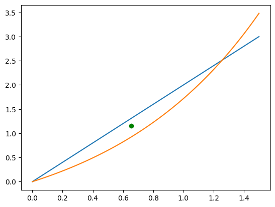

```python
from matplotlib.pyplot import plot
from numpy import linspace
x = linspace(0, 1.5, 100)

# Find intersections of y=2*x & y = e^x - 1
from scipy.optimize import fsolve
u = lambda x: 2*x
l = lambda x: exp(x) - 1
x1 = fsolve(lambda x: u(x)-l(x), x0=1)[0]
print(x1)

# Compute center of mass
M = dblquad(lambda y, x: 1, 0, x1, l, u)[0]
My = dblquad(lambda y, x: x, 0, x1, l, u)[0]
Mx = dblquad(lambda y, x: y, 0, x1, l, u)[0]
print(My/M, Mx/M)
plot(x, 2*x, x, exp(x)-1, My/M, Mx/M, 'go')
```

### Triple integrals

Back to Top

`I, e=tplquad(f, a, b, l, u, q, r)` calculates $$\int_a^b\int_{\ell}^{u}\int_q^rf(z,y,x)dzdydx$$

- $f(z, y, x)$ is a two-variable function
  - $z$ must be the first argument
  - Also applies to lambda functions!!!
- $a$ and $b$ are the lower and upper limits of the outer integral.
- $\ell$ and $u$ are single variable functions (or float numbers) specifying the lower and upper limits of the middle integral
- $q$ and $r$ are two variable functions of $x$ and $y$ (or float numbers) specifying the lower and upper limits of the inner integral
- it returns the approximated integral with an error estimate

### Ex: Center of mass of 3D volume

Back to Top

For a region $R\subset \mathbb R^3$, the center of mass is defined as $\displaystyle\left(\frac{M_{yz}}{M}, \frac{M_{xz}}{M}, \frac{M_{xy}}M\right)$ where \begin{align} M & = \iiint_Rdxdy \\ M_{yz} & = \iiint_Rxdxdy \\ M_{xz} & = \iiint_Rydxdy\\ M_{xy} & = \iiint_Rzdxdy \end{align}

```python
from scipy.integrate import tplquad
r = lambda theta, r: 4-r**2

M = tplquad((lambda z,r,theta: r), 0, 2*pi, 0, 2, 0, r)[0]
Mxy = tplquad((lambda z,r,theta: r*z), 0, 2*pi, 0, 2, 0, r)[0]
Mxy/M
```

```
1.3333333333333335
```

### Multiple integrals in general: `nquad` (best for quad)

Back to Top

`I, e=nquad(f, bounds)` calculates the above integral

- $f(x_0, x_1,\dots, x_n)$ is an $n$-variable function
  - $x_0$ is the dummy variable of the innermost integral
- `bounds` is a list of bounds, each bound is
  - either a list of two float numbers, the lower and upper limits
  - or a function that returns a list containing the lower and upper limits
    - The function takes all the available bounds, in the order from inner to outer dummy variables.
  - the list is also ordered from the inner to outer dummy variables
- it returns the approximated integral with an error estimate

Note that the variable order fo the bounds, and the order of the bounds** are the opposite of `dblquad`and `tplquad`

```python
# Same example as last:

from scipy.integrate import nquad
r = lambda r, theta: [0, 4-r**2]

M = nquad(lambda z,r,theta: r, [r, [0, 2], [0, 2*pi]])[0]
Mxy = nquad(lambda z,r,theta: r*z, [r, [0, 2], [0, 2*pi]])[0]
# Note that using nquad retains order; In dblquad (etc.) order in lambda
# is opposite of order of bounds, nquad always first integration to last, R to L
Mxy/M
```

```
1.3333333333333335
```

### Ex: Rolling shell vs ball

Back to Top

(1) We first need to compute the density of the shell, $$\rho = \frac{\text{volume of the ball}}{\text{volume of the shell}}$$

where $$V_{\text{ball}} = \int_0^{2\pi}\int_0^{\pi}\int_0^1 r^2\sin\phi drd\phi d\theta$$

$$V_{\text{shell}} = \int_0^{2\pi}\int_0^{\pi}\int_{0.5}^1 r^2\sin\phi drd\phi d\theta$$

(2) We then need to compute $I_z$ for the shell: $$I_z = \rho\int_0^{2\pi}\int_0^{\pi}\int_{0.5}^1 r^4\sin^3\phi drd\phi d\theta$$

```python
from scipy.integrate import tplquad

# Moment of inertia of ball w radius 1, denity profile p(x,y,z)
# along z axis;
# x^2 + y^2 = r^2 gives
f = lambda r, phi, theta: r**4 * sin(phi)**3

# (1)
Vball = tplquad(lambda r, phi, theta: r**2*sin(phi), 0, 2*pi, 0, pi, 0, 1)[0]
Vshell = tplquad(lambda r, phi, theta: r**2*sin(phi), 0, 2*pi, 0, pi, 0.5, 1)[0]

rho = Vball/Vshell
print(rho)

# (2)
tplquad(f, 0, 2*pi, 0, pi, 0.5, 1)[0]*rho
```

```
1.1428571428571428
```

```
1.855035662119687
```

Because the moment of inertia of the shell is larger, it rolls slower.

## Optimization

Back to Top

Min/max of a function

$\displaystyle \max_{x} f(x)$ is equivalent to $\displaystyle \min_{x}-f(x)$

### Linear programming w `scipy.optimize`

Back to Top

`linprog(c, A_ub, b_ub, A_eq, b_eq, bounds)` Solves \begin{align} \min_x & & c^Tx \\ \text{subject to} & & A_{ub}x\leq b_{ub}\\ & & A_{eq}x = b_{eq}\\ & & l\leq x\leq u \end{align}

Usage: `linprog(c, A_ub, b_ub, A_eq, b_eq, bounds)`:

- If a corresponding constraint does not exist, pass `None` to the corresponding argument
- bounds: A sequence of (min, max) pairs for each element in x, defining the minimum and maximum values of that decision variable. Use None to indicate that there is no bound. By default, bounds are (0, None) (all decision variables are non-negative). If a single tuple (min, max) is provided, then min and max will serve as bounds for all decision variables.
- Return value: an object containing at least the following instance varibles
- `x`: The values of the decision variables that minimizes the objective function while satisfying the constraints.
- `fun`: The optimal value of the objective function $c\dot x$.
- `success`: True when the algorithm succeeds in finding an optimal solution.
- `status`: An integer representing the exit status of the algorithm.
  - 0 : Optimization terminated successfully.
  - 1 : Iteration limit reached.
  - 2 : Problem appears to be infeasible.
  - 3 : Problem appears to be unbounded.
  - 4 : Numerical difficulties encountered.
- `message`: A string descriptor of the exit status of the algorithm.

Example: \begin{align} \max_{x,y} & & 2x + 5y\\ s.t. & & 100\leq x\leq 200\\ & & 80 \leq y \leq 170\\ & & x + y \geq 200 \end{align}

Meed min, thus solve \begin{align} \min_{x,y} & & -2x -5y\\ s.t. & & 100\leq x\leq 200\\ & & 80 \leq y \leq 170\\ & & -x -y \leq -200 \end{align}

```python
from scipy.optimize import linprog
linprog(c=[-2, -5], A_ub=[[-1, -1]], b_ub = -200, bounds=[(100, 200), (80, 170)])
```

```
        message: Optimization terminated successfully. (HiGHS Status 7: Optimal)
        success: True
         status: 0
            fun: -1250.0
              x: [ 2.000e+02  1.700e+02]
            nit: 0
          lower:  residual: [ 1.000e+02  9.000e+01]
                 marginals: [ 0.000e+00  0.000e+00]
          upper:  residual: [ 0.000e+00  0.000e+00]
                 marginals: [-2.000e+00 -5.000e+00]
          eqlin:  residual: []
                 marginals: []
        ineqlin:  residual: [ 1.700e+02]
                 marginals: [-0.000e+00]
 mip_node_count: 0
 mip_dual_bound: 0.0
        mip_gap: 0.0
```

Thus the max is 1250 at (200, 170)

### Ex: Linear programming 2

Back to Top

$$ \begin{align} \max_{x,y} & & x-4y\\ s.t. & & -3x+y\leq 6\\ & & -x -2y \geq -4\\ & & y\geq -3 \end{align} $$ We cannot directly apply `linprog` to this example:

- This is a maximization problem
- The inequality contraints are not all in the "upper bound" format $A_{ub}x\leq b$

\begin{align} - \min_{x,y} & &x-4y \\ s.t. & & -3x+y\leq 6\\ & & x+2y\leq4\\ & & y\geq -3 \end{align}

```python
c = [-1, 4]
A_ub=[[-3, 1], [1, 2]]
b_ub=[6, 4]
A_eq = None
b_eq = None
x_bounds = [None, None]
y_bounds = [-3, None]

x = linprog(c=c, A_ub=A_ub, b_ub=b_ub, bounds=[x_bounds, y_bounds])
print(x)
print("max:", -x.fun)
```

```
        message: Optimization terminated successfully. (HiGHS Status 7: Optimal)
        success: True
         status: 0
            fun: -22.0
              x: [ 1.000e+01 -3.000e+00]
            nit: 0
          lower:  residual: [       inf  0.000e+00]
                 marginals: [ 0.000e+00  6.000e+00]
          upper:  residual: [       inf        inf]
                 marginals: [ 0.000e+00  0.000e+00]
          eqlin:  residual: []
                 marginals: []
        ineqlin:  residual: [ 3.900e+01  0.000e+00]
                 marginals: [-0.000e+00 -1.000e+00]
 mip_node_count: 0
 mip_dual_bound: 0.0
        mip_gap: 0.0
max: 22.0
```

### Ex: Linear programming 3

Back to Top

\begin{align} \max_{x,y} & &5x-y\\ s.t. & &0\leq x\leq7\\ & &-2\leq y<\leq2\\ & & x+y\geq3\\ & &x-y\leq2 \end{align}

```python
from scipy.optimize import linprog
import numpy as np

# Set variables
# Note: Maximization thus must rearrange (4)
c = [-5, 1]
A_ub = [[-1, -1], [1, -1]]
b_ub = [-3, 2]
x_bounds = [0, 7]
y_bounds = [-2, 2]

x = linprog(c=c, A_ub=A_ub, b_ub=b_ub, bounds=[x_bounds, y_bounds])
print("max:", -x.fun)
print("occurs at:", x.x)
```

```
max: 18.0
occurs at: [4. 2.]
```

### Nonlinear unconstrained optimization; `minimize(f, x0)`

Back to Top

Solve $$\min_{x,y} f(x, y) = (1-x)^2 + (y-x^2)^2$$ The true minimum is at $(1,1)$, and $f(1,1)=0$

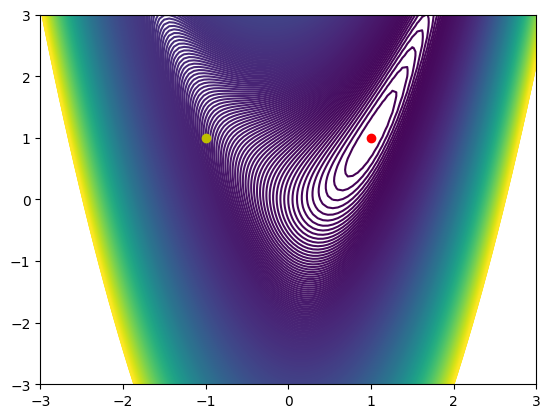

```python
from scipy.optimize import minimize
from numpy import array, linspace, zeros
from matplotlib.pyplot import contour, plot

fxy = lambda x, y: (1-x)**2 + (y-x**2)**2
# the minimize function requires f(x) to have a single array argument,
# not two arguments xc and y
f = lambda x: fxy(x[0], x[1])


x = linspace(-3, 3, 101)
y = linspace(-3, 3, 101)

levels = linspace(0, 50, 501)

z = zeros((len(x), len(y)))
for i in range(len(x)):
    for j in range(len(y)):
        z[i, j] = fxy(x[i], y[j])

contour(x, y, z.T, levels)
plot(1, 1, "-ro", -1, 1, '-yo')
```

```python
minimize(f, x0=array([-1, 1]))
```

```
  message: Optimization terminated successfully.
  success: True
   status: 0
      fun: 4.601649903156427e-15
        x: [ 1.000e+00  1.000e+00]
      nit: 13
      jac: [-1.012e-07  3.571e-08]
 hess_inv: [[ 5.066e-01  1.009e+00]
            [ 1.009e+00  2.514e+00]]
     nfev: 48
     njev: 16
```

### Ex: minimize

Back to Top

$$\min_{x} x^4-2x^3$$

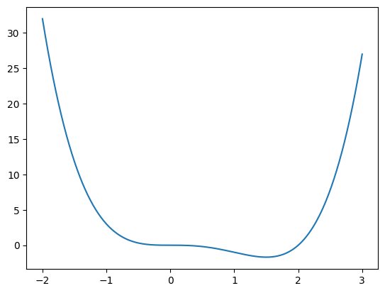

```python
f = lambda x: x**4 - 2*x**3

t = linspace(-2, 3, 601)
plot(t, f(t))
```

```python
minimize(f, 10)
```

```
  message: Optimization terminated successfully.
  success: True
   status: 0
      fun: -1.6875
        x: [ 1.500e+00]
      nit: 14
      jac: [ 0.000e+00]
 hess_inv: [[ 1.110e-01]]
     nfev: 30
     njev: 15
```

### Ex: Minimize distance from point to ellipse

Back to Top

Find the point on the ellipse $$x^2+4y^2=1$$ that is closest to the point $p=(1, \sqrt{2})$.

```
Minimum at theta = [0.91580282]
or at point [0.6091540915172478, 0.3965259426531247]
```

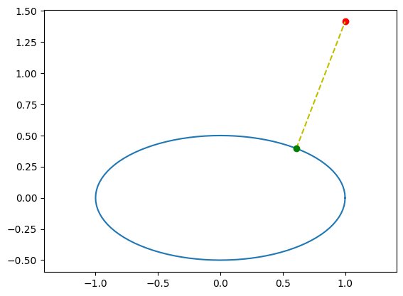

```python
from scipy.optimize import minimize
import numpy as np
import matplotlib.pyplot as plt

# Parametrize, find min theta:o
x = lambda x: np.cos(x)
y = lambda y: np.sin(y) * 0.5
o = np.linspace(0, 2*np.pi, 101)

# We know the distance equation is
# sqrt((x - a)**2 + (y - b)**2),
# Want to minimize
p = [1, np.sqrt(2)]
d = lambda o: np.sqrt((p[0]-x(o))**2 + (p[1]-y(o))**2)
#
m = minimize(d, 2)
print("Minimum at theta =", m.x)
print("or at point", [x(m.x[0]), y(m.x[0])])

fig, axs = plt.subplots()
axs.axis('equal')
# Plot ellipse, point,
# line from point to ellipse and closest point
plt.plot(x(o), y(o))
plt.plot(p[0], p[1], 'or')
xl = [x(m.x[0]), p[0]]
yl = [y(m.x[0]), p[1]]
plt.plot(xl, yl,'--y')
plt.plot(x(m.x[0]), y(m.x[0]), 'og')
```

### Ex: Least square, exponential

Back to Top

$$x(t)=ae^{rt}$$ We want $a,r\geq0$ \begin{align} \min_{x_0, r} & & \sum_i (x_i - ae^{rt_i})^2\\ s.t. & & x_0\geq 0\\ & & a\geq 0 \end{align}

```
 [Text(3, 0, '3'), Text(10, 0, '10'), Text(17, 0, '17'), Text(24, 0, '24')])
```

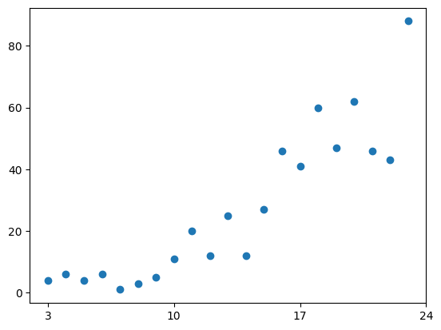

```python
# Graph
from matplotlib.pyplot import xticks
t = array(range(3, 24))
x = array([4,6,4,6,1,3,5,11,20,12,25,12,27,46,41,60,47,62,46,43,88])

plot(t, x, "o")
xticks([3, 10, 17, 24])
```

If two quantities $x$ and $t$ have an exponential relationship, $x=x_0e^{rt}$, then $\ln x$ and t has a linear relationship $$\ln x = \ln x_0 +rt$$ So, we can also minimize the difference between the log of data and this straight line.

```
  message: CONVERGENCE: NORM_OF_PROJECTED_GRADIENT_<=_PGTOL
  success: True
   status: 0
      fun: 6.174827320754678
        x: [ 1.567e+00  1.765e-01]
      nit: 16
      jac: [ 7.994e-07 -2.220e-06]
     nfev: 54
     njev: 18
 hess_inv: <2x2 LbfgsInvHessProduct with dtype=float64>
```

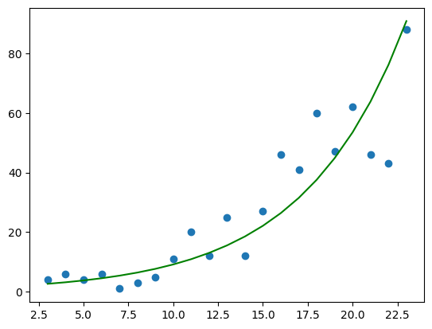

```python
# Note we have to use log of data, since exponential
from numpy import log
Ln = lambda t, p: log(p[0]) + p[1]*t
f = lambda p: sum((log(x) - Ln(t, p))**2)

fit = minimize(f, [1, 1], bounds=[(0, None), (0, None)])
p1 = fit.x
print(fit)

plot(t, x, 'o', t, Exp(t, p1), '-g')
```

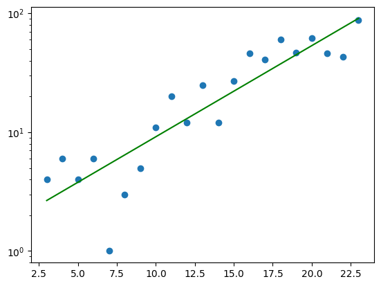

```python
from matplotlib.pyplot import semilogy
semilogy(t, x, 'o', t, Exp(t, p1), '-g')
```

### Ex: Solving exponential for time

Back to Top

For an exponentially growing curve $x(t)=x_0e^rt$, how long does it take for $x(t)$ to double?

$$2x_0=x_0e^{rT}, T=\frac{\ln2}{r}$$

```python
print("take r=", p[1], "T=", log(2)/p[1], "days")
print("take r=", p1[1], "T=", log(2)/p1[1], "days")
```

```
take r= -0.024234098279624017 T= -28.60214448922748 days
take r= 0.17650687493841197 T= 3.9270265297133786 days
```

### Ex: Parameter estimation; poisson regression

Back to Top

$$\min_{a,r} \sum_{i=1}^n\mu I_t-x_i\ln (\mu I_t)$$

We use $t_i=0,1,2,...$, i.e., days since the start of the data, $\mu I_t = \lambda_t =$ mean

```
  message: CONVERGENCE: REL_REDUCTION_OF_F_<=_FACTR*EPSMCH
  success: True
   status: 0
      fun: -65116.863961014315
        x: [ 1.412e+01  1.539e+01  3.940e+00  1.467e-01  1.000e+00
             1.976e-03]
      nit: 96
      jac: [-1.397e-01  1.266e-01 -1.899e-01 -3.102e+00  9.726e+00
            -7.276e+01]
     nfev: 924
     njev: 132
 hess_inv: <6x6 LbfgsInvHessProduct with dtype=float64>
```

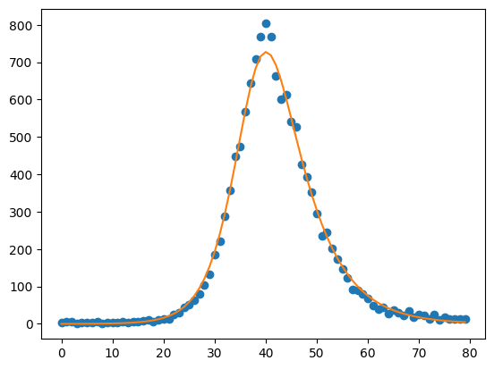

```python
from numpy import arange, zeros, array, log
from pandas import read_csv

data = read_csv("Philadelphia-1918.csv", sep=" ", names=["t", "x"])

t = arange(0, 80)
x = data.x[0:80]

S0 = 1e6
def deaths(t, p):
    E0, I0, beta, sigma, gamma, mu = p
    X = zeros([len(t), 4])
    X[0, 0] = S0
    X[0, 1] = E0
    X[0, 2] = I0
    X[0, 3] = 0
    for i in range(1, len(t)):
        S, E, I, R = X[i-1, :]
        N = S + E + I + R
        X[i, :] = array([S - beta*S*I/N,
                         E + beta*S*I/N - sigma*E,
                         I + sigma*E - gamma*I - mu*I,
                         R + gamma*I])
    return X[:, 1]*mu

def l(p):
    muIt = deaths(t, p)
    return sum(muIt - x*log(muIt))

E0 = 3
I0 = 3
beta = 0.5
sigma=0.5
gamma =0.25
mu = 0.01

from scipy.optimize import minimize
m = minimize(l, [E0, I0, beta, sigma, gamma, mu],
             bounds=[(1, 100), (1, 100), (0.01, None), (1e-4, 1), (1e-4, 1), (1e-4, 1)]) # Originally 1e-6
print(m)
plot(t, x, 'o', t, deaths(t, m.x))
```

### Ex: Implied constraints - ln(x)

Back to Top

```python
from scipy.optimize import minimize
from numpy import log

f = lambda x: log(x)**2
# Doesn't work
minimize(f, 10)
# Works
minimize(f, 10, bounds=[(1e-6, None)])
```

```
  message: CONVERGENCE: NORM_OF_PROJECTED_GRADIENT_<=_PGTOL
  success: True
   status: 0
      fun: 7.12392540530006e-13
        x: [ 1.000e+00]
      nit: 5
      jac: [-1.678e-06]
     nfev: 30
     njev: 15
 hess_inv: <1x1 LbfgsInvHessProduct with dtype=float64>
```

### Linear, nonlinear constraints

Back to Top

`LinearConstraint(A, lb, ub, keep_feasible=False)` describes a linear constraint $$\ell_b\leq Ax\leq u_b$$

`NonlinearConstraint(g, lb, ub)` defines a constraint $$\ell_b\leq g(x)\leq u_b$$

```python
# Linear ex:
f = lambda x: log(x)**2
from scipy.optimize import LinearConstraint
from numpy import *

# 0 <= x
xx = minimize(f, [10], constraints = [LinearConstraint(array([[1]]), 0.1, inf, True)])

# Nonlinear ex:
from scipy.optimize import NonlinearConstraint

xy = minimize(lambda x: x[0]**2 + x[1]**2, [1, 3],
        constraints = [NonlinearConstraint(lambda x: x[1]-x[0]**2, 3, inf)])

print(xx, xy)
```

```
 message: Optimization terminated successfully
 success: True
  status: 0
     fun: 3.6151157402110044e-07
       x: [ 1.001e+00]
     nit: 16
     jac: [ 1.202e-03]
    nfev: 42
    njev: 16  message: Optimization terminated successfully
 success: True
  status: 0
     fun: 8.999999999256929
       x: [-2.869e-09  3.000e+00]
     nit: 8
     jac: [ 0.000e+00  6.000e+00]
    nfev: 27
    njev: 8
```

### Ex: Regression, exponential growth scale

Back to Top

To maximize $\ell(a,r)$ is equivalent to minimize $-\ell(a,r)$. In addition, since the observations $x_i$ are constants, $\ln x_i!$ do not change the solution to $(a,r)$. Thus $$\min_{a,r} \sum_{i=1}^n f(t_i;a,r) - x_i\ln f(t_i;a,r)$$

We use $t_i=0,1,2,...$, i.e., the days since the start of the data.

To solve this problem, we assume that a logistic model describes the cumulative death curve, i.e., $$y(t;a, r) = \frac{K}{1+(\frac K a-1)e^{-rt}}$$ where $K$ is the total number of cases. So $K$ is the sum of all case counts in the spread sheet. (i.e, `K=sum(data.x)`)

The mean deaths $$f(t_i;a, r)=y(t_{i+1}; a, r)-y(t_i; a, r)$$

We fit from the start to the peak of the death curve for the parameters $a, r$

- i.e, use `n=list(data.x).index(max(data.x)) + 1`

```
  message: CONVERGENCE: REL_REDUCTION_OF_F_<=_FACTR*EPSMCH
  success: True
   status: 0
      fun: -30790.54038444412
        x: [ 5.874e-01  2.396e-01]
      nit: 20
      jac: [ 2.547e-03 -2.437e-02]
     nfev: 72
     njev: 24
 hess_inv: <2x2 LbfgsInvHessProduct with dtype=float64>
```

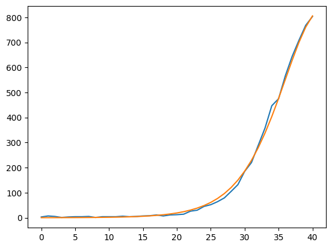

```python
import pandas as pd
import numpy as np
from scipy.optimize import minimize
import matplotlib.pyplot as plt

data = pd.read_csv('Philadelphia-1918(1).csv', delimiter=" ")

n = list(data.Deaths).index(max(data.Deaths))+1

K = sum(data.Deaths)
x = data.Deaths[0:n]

t = np.arange(0, n)

y = lambda t, p: K / (1 + ((K/p[0])-1)*np.exp(-p[1]*t))
f = lambda t, p: y(t+1, p) - y(t, p)

F = lambda p: sum(f(t, p) - x*np.log(f(t, p)))

m = minimize(F, [3, 0.2], bounds=[(1e-6, None), (1e-6, None)])
print(m)

plt.plot(t, x)
plt.plot(t, f(t, m.x))
```

### Ex: Least square regression using minimize

Back to Top

Use the least square method to find a quadratic function $y=ax^2+bx+c$ that minimizes its distance to the points.

```
  message: Optimization terminated successfully.
  success: True
   status: 0
      fun: 1.1859819389029238
        x: [ 1.079e+00  1.044e+00 -3.062e+00]
      nit: 5
      jac: [-1.490e-08  0.000e+00  0.000e+00]
 hess_inv: [[ 3.160e-02  3.160e-02 -1.738e-02]
            [ 3.160e-02  5.176e-02 -7.300e-03]
            [-1.738e-02 -7.300e-03  3.073e-02]]
     nfev: 28
     njev: 7
```

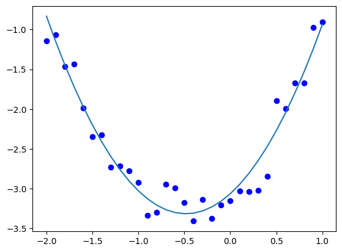

```python
import pandas as pd
from scipy.optimize import minimize
import numpy as np
import matplotlib.pyplot as plt

# Plot data
data = pd.read_csv('points.csv')
xs = data.x
ys = data.y

# Minimize difference between points and y = ax^2 + bx + c
poly = lambda t, p: p[0]*t**2 + p[1]*t + p[2]
f = lambda p: sum((ys - poly(xs, p))**2)
fit = minimize(f, [-1,-1,-1])
p = fit.x
print(fit)

# Plot points & line
plt.plot(xs, ys, 'ob')
plt.plot(xs, poly(xs, p))
```